# Лабораторная работа № 14

# Самостоятельная работа

## Создание разделов с помощью gdisk

Создали разделы на диске /dev/sdc с помощью gdisk

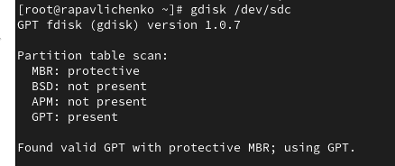

## Создание первого раздела

Создали первый раздел размером 100 MiB

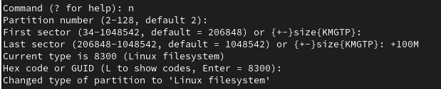

## Создание раздела подкачки

Создали второй раздел с типом Linux Swap

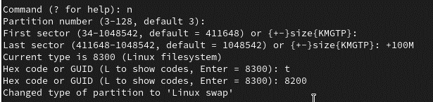

## Просмотр таблицы разделов

Просмотрели планируемую таблицу разделов

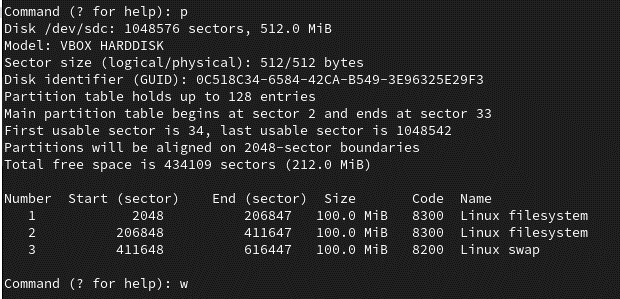

## Обновление таблицы разделов

Обновили таблицу разделов в ядре

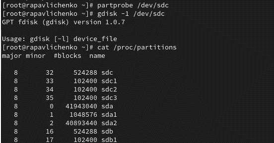

## Форматирование разделов

Отформатировали разделы подкачки и ext4

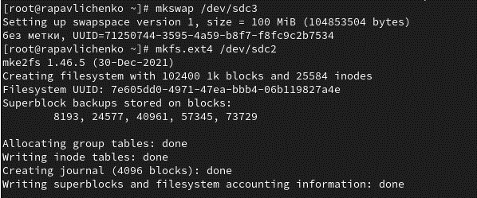

## Создание точки монтирования и определение UUID

Создали точку монтирования и определили UUID разделов

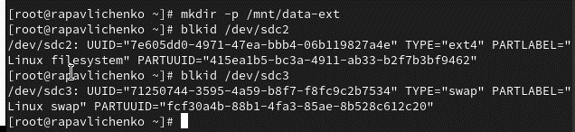

## Редактирование fstab

Настроили автоматическое монтирование в /etc/fstab

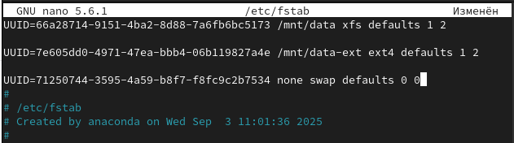

## Проверка монтирования и активации swap

Проверили монтирование ext4 и активировали swap

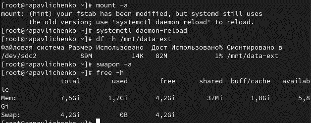

## Перезагрузка системы

Перезагрузили систему для проверки настроек

## Проверка после перезагрузки

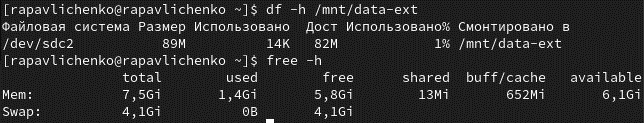

# Выводы

## Итоги работы

- Получены практические навыки работы с разделами диска
- Освоены инструменты fdisk и gdisk для MBR и GPT
- Приобретены навыки создания файловых систем XFS и EXT4
- Изучены методы монтирования и автоматического монтирования
- Получен опыт работы с разделами подкачки